# Regression and model validation

**Summary of week2 study**

- *In week2, I self-studied the data wrangling skills, simple data visulization, single and multi variant(s) regression, regression diagnostics, model validation and prediction from [DataCamp](https://campus.datacamp.com/courses/helsinki-open-data-science/regression-and-model-validation?ex=1);*
- *I have learnt not only the actual skills of regression analysis, but also the knowledge of how and why we need to model the data, and how to validate & use the models.*

```r
# Loading packages
library(ggplot2)
library(GGally)
```

## 1. Read the data

```r
# Read the new dataset from the loal folder and named it as learning2014.
learning2014 <- read.csv("data_ready_for_analysis_week2.txt")
# The first few heading lines in learning2014.
head(learning2014)
```

```
##   gender age attitude     deep  stra     surf points
## 1      F  53      3.7 3.583333 3.375 2.583333     25
## 2      M  55      3.1 2.916667 2.750 3.166667     12
## 3      F  49      2.5 3.500000 3.625 2.250000     24
## 4      M  53      3.5 3.500000 3.125 2.250000     10
## 5      M  49      3.7 3.666667 3.625 2.833333     22
## 6      F  38      3.8 4.750000 3.625 2.416667     21
```

```r
# learning2014 has 183 rows with 7 columns.
dim(learning2014)
```

```
## [1] 183   7
```

```r
# learning2014 is a dataframe, and it contains 7 variables realated to 183 observations.
str(learning2014)
```

```
## 'data.frame':    183 obs. of  7 variables:
##  $ gender  : Factor w/ 2 levels "F","M": 1 2 1 2 2 1 2 1 2 1 ...
##  $ age     : int  53 55 49 53 49 38 50 37 37 42 ...
##  $ attitude: num  3.7 3.1 2.5 3.5 3.7 3.8 3.5 2.9 3.8 2.1 ...
##  $ deep    : num  3.58 2.92 3.5 3.5 3.67 ...
##  $ stra    : num  3.38 2.75 3.62 3.12 3.62 ...
##  $ surf    : num  2.58 3.17 2.25 2.25 2.83 ...
##  $ points  : int  25 12 24 10 22 21 21 31 24 26 ...
```

For the other 4 variables, the mean values are taken from the related columns. For example, `attitude` is the mean of 10 variables (`rowsum(Da+Db+Dc+Dd+De+Df+Dg+Dh+Di+Dj)`) from the original dataset. The ten variables are measured from the following five perspectives:

- Confidence in doing statistics
- Value of statistics
- Interest in statistics
- Confidence in doing math
- Affect toward statistics

`deep` stands for three deep approches combined from 12 original variables. It measures:

- Seeking Meaning
- Relating Ideas
- Use of Evidence

`stra` means strategic approach normalized from 8 original variables. It measures:

- Organized Studying
- Time Management

`surf` stands for surface approach from 12 original variables. It measures:

- Lack of Purpose
- Unrelated Memorising
- Syllabus-boundness

For further information, please check the [online information](http://s3.amazonaws.com/assets.datacamp.com/production/course_2218/datasets/learning2014.txt) and the [local script](https://github.com/QingliGuo/IODS-project/Data/Data_wrangling_IODS_week2.R).

## 2. Graphical overview of the data

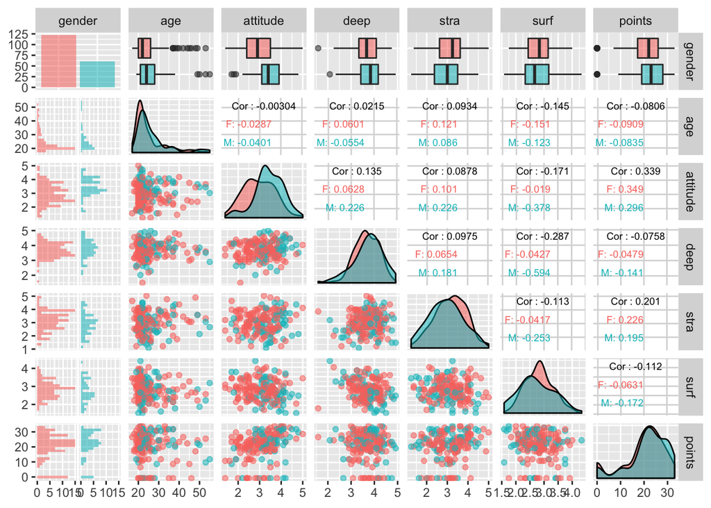

```r
ggpairs(learning2014, mapping = aes(color=gender,alpha=0.3),
        lower = list(combo =wrap("facethist", bins = 20)),
        upper = list(continuous = wrap("cor", size = 2.5)))
```

From the pair-wise comparison plot, we got a lot of information about `learning2014`.

- 1. The size of female students is around twice bigger than the male student size. However, the distribution and the mean of female & male group do not show a big difference in most of the variables, except for attitude. It could be observed by the **histogram**, **box** and **density** plots.
- 2. We can also check the correlation coeffients between the non-factor varibles (num of col =[2:7]). Regardless of the gender, correlation of `attitude` vs `points`, `stra` vs `points` are the two highest, with 0.339 and 0.201, respectively. In contrast, `surf` shows a negtive correlation (-0.112) with the final total `points`. Besides, `deep` and `attitude` are showing a positive correlation (0.135). Taking the gender into consideration, the famele and male students are generally sharing the same correlation trend. The only exception is between `deep` approach with `age`, which female group shows a positive trend but negtive for the male students.

## 3. Fitting the linear regression model

```r
# Fit a multi-variant linear regression model by taking points as target variable and three dependent variables (attitude, stra and surf).
my_model <- lm(points ~ attitude + stra + surf, data = learning2014)

# summary the regression model
summary(my_model)
```

```
##
## Call:
## lm(formula = points ~ attitude + stra + surf, data = learning2014)
##
## Residuals:
##     Min      1Q  Median      3Q     Max
## -25.151  -3.212   2.233   5.257  13.694
##
## Coefficients:
##             Estimate Std. Error t value Pr(>|t|)
## (Intercept)   4.7781     5.1577   0.926   0.3555
## attitude      3.7570     0.8308   4.522 1.11e-05 ***
## stra          1.8968     0.7832   2.422   0.0164 *
## surf         -0.6262     1.1494  -0.545   0.5866
## ---
## Signif. codes:  0 '***' 0.001 '**' 0.01 '*' 0.05 '.' 0.1 ' ' 1
##
## Residual standard error: 8.082 on 179 degrees of freedom
## Multiple R-squared:  0.146,  Adjusted R-squared:  0.1317
## F-statistic:  10.2 on 3 and 179 DF,  p-value: 3.089e-06
```

Firstly, we have fitted three denpendent variables(`attitude`, `stra` and `surf`) and a target variable `points`, based on the absolute correlation coefficient with `points`, to a three-variant regression model:
$$y=b+a1*x1+a2*x2+a3*x3+error$$

The model summary tells us:

- The Intercept `b` is 4.7781. It means points will be 4.7781 when `attitude`, `stra` and `surf` are zero.
- The coefficient of `x1` (`attitude`) is 3.7570. The estimation of it is very significant with near zero *p* value. The *p* value basically tells us the probability of accepting null hypothesis, which is `attitude` has no contribution to `points`.
- The coefficient of `x2` (`stra`) is 1.8968, which passed the significance test with the cutoff 0.05.
- The coefficient of `x3` (`surf`) is -0.6262. The statistic test is not significant for `surf`, which has around 58% of probablity to accept the null hypothesis.

Thus, we will fit a two-variable model for `points`:

```r
# Fit a multi-variant linear regression model by taking points as target variable and two dependent variables (attitude and stra).
my_newmodel <- lm(points ~ attitude + stra, data = learning2014)

# summary the regression model
summary(my_newmodel)
```

```
##
## Call:
## lm(formula = points ~ attitude + stra, data = learning2014)
##
## Residuals:
##     Min      1Q  Median      3Q     Max
## -25.162  -3.029   1.911   5.078  13.720
##
## Coefficients:
##             Estimate Std. Error t value Pr(>|t|)
## (Intercept)   2.6680     3.3993   0.785   0.4336
## attitude      3.8308     0.8181   4.683 5.56e-06 ***
## stra          1.9394     0.7777   2.494   0.0135 *
## ---
## Signif. codes:  0 '***' 0.001 '**' 0.01 '*' 0.05 '.' 0.1 ' ' 1
##
## Residual standard error: 8.066 on 180 degrees of freedom
## Multiple R-squared:  0.1446, Adjusted R-squared:  0.1351
## F-statistic: 15.22 on 2 and 180 DF,  p-value: 7.843e-07
```

- The Intercept `b` is 2.6680. It means points will be 2.6680 when `attitude` and `stra` equal zero.
- The coefficient of `x1` (`attitude`) is 3.8308. It means the `attitude` value can contribute about 3.8 times to the final `points`.
- The coefficient of `x2` (`stra`) is 1.9394. It means the `stra` value can contribute about 1.9 times to the final `points`.

## 4. Model diagnostic

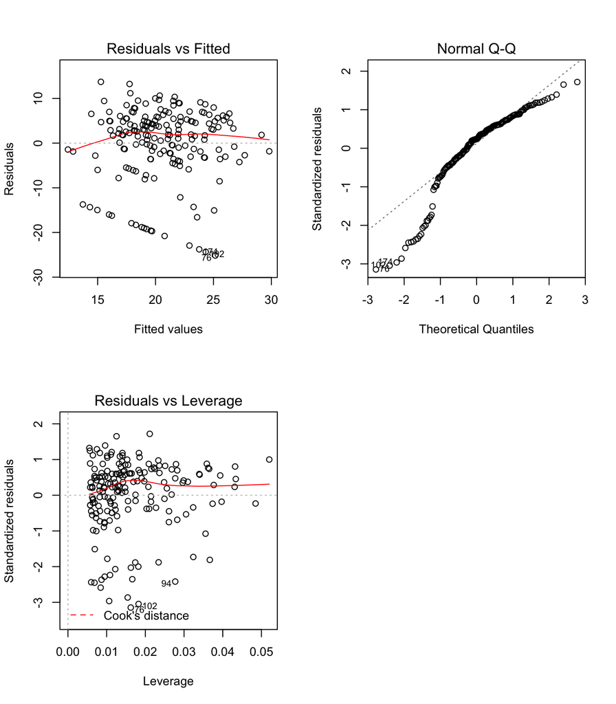

```r
par(mfrow = c(2,2))
plot(my_newmodel,which=c(1,2,5))
```

Here we used a linear regression model to fit our data. The assumption of it is:

- The target variable is the linear combination of the dependent parameters.
- The errors (residuals) are normally distrubuted
- The errors are not correlated with the target.
- The errors should have a constant variance.
- The errors are not dependent on the expaintory variables.

From the diagnostic plots:

- 1. The residuals have a constant variance, are resonably linear.
- 2. The Normal Q-Q plot shows most of the residuals are normally distributed but it is not the case for the two tails.
- 3. Even with outliars. They are not be influential to determine a regression line.